# AIM

The aim is to try spict as assessment model for Northern White Anglerfish in Division 7a-k and compare the results with the outputs of the actual assessment model a4a. The a4a model get information from three surveys:

FR_IE_IBTS survey: the joint index of the French EVHOE survey and the Irish IBTS survey. Both are conducted between the third and forth quarter.The French EVHOE survey is conducted in the Bay of Biscay and the Irish IBTS in the Celtic Sea.

The Spanish survey in the Porcupine Bank began in 2001 and covers ICES Divisions VIIb-k corresponding to the Porcupine Bank and adjacent area in western Irish waters. The survey takes place in the third quarter (September) and covers depths between 170 and 800 m.

Monkfish survey is in the beginning of the year, but is considered the end of the previous year and it’s conducted in the Celtic Sea.

```r
library(devtools)
install_github("DTUAqua/spict/spict")
```

Load all necessary packages.

```r
library(spict)
```

# Input data

```r
data.ang <- read.csv("data_Spict.csv")
summary(data.ang)

data.ang$Year <- as.numeric(data.ang$Year)
data.ang$timeEv <- ifelse(data.ang$Year>=2003 & data.ang$Year!= 2017,data.ang$Year+(0.75+1)/2,NA)
data.ang$timePP <- ifelse(data.ang$Year>=2001,data.ang$Year+(0.75+1)/2,NA)
data.ang$timeMon <- ifelse(data.ang$Year %in% c(2005,2006,2015:2019),data.ang$Year+1/12*11.5,NA)
data.ang$timeMon2 <- ifelse(data.ang$Year >= 2015, data.ang$Year+1/12*11.5,NA)

attach(data.ang)
```

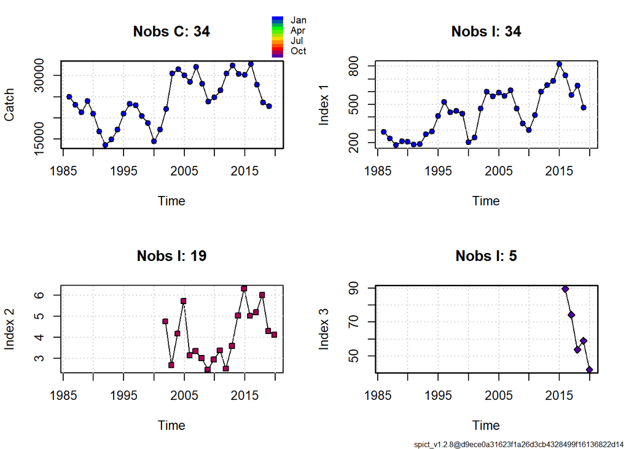

```r
dtc=1
dteuler=1/16
inp.ang <- list(obsC=Total_Catch,timeC=Year,
                obsI=list(LPUE_Vigo, SPPGFS,MON2),
                timeI=list(Year,timePP,timeMon2),
                dtc=dtc,dteuler=dteuler)
inp.ang$phases$logbeta <- 1
inp.ang$phases$logalpha <- 1
inp <- check.inp(inp.ang)
#' Plot the input data
plotspict.data(inp, qlegend = TRUE)
```

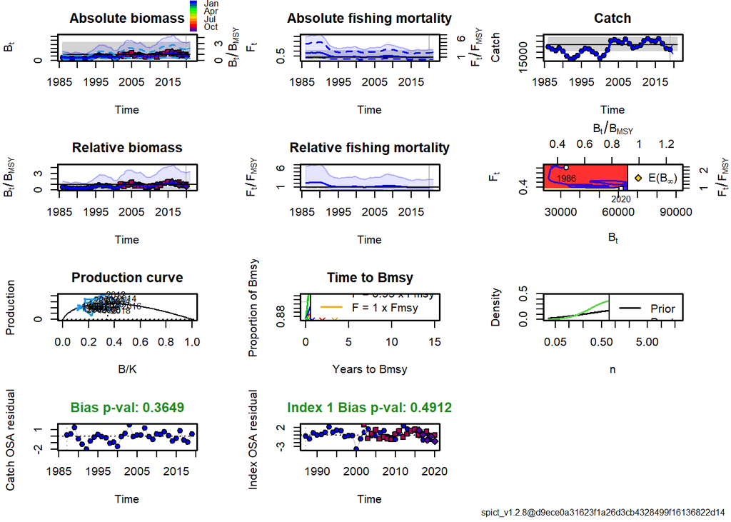

```r
res <- fit.spict(inp)
summary(res)
res<- calc.osa.resid(res)

plot(res)
```

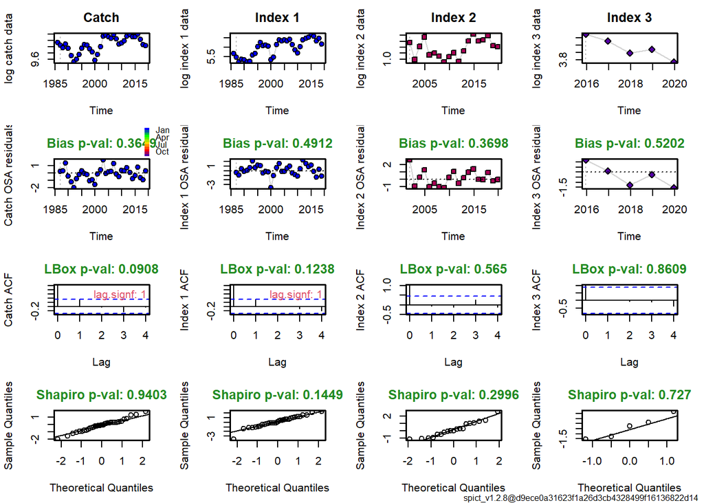

```r
#plotspict.osar(rep)


# Plot the residual diagnostics
plotspict.diagnostic(res)
```

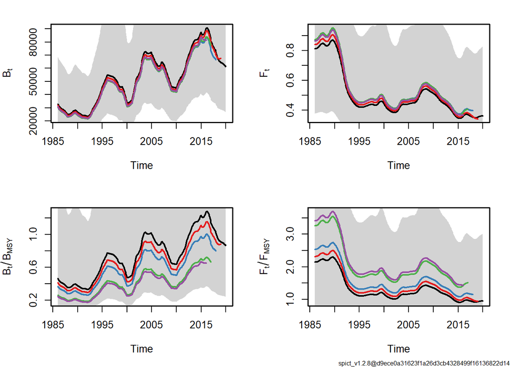

```r
# Check the sensitivity to initial parameter values
sens.ini <- check.ini(res, ntrials = 5)

# Make a retrospective analysis and plot the results
res$inp$getReportCovariance = FALSE
res <- retro(res, nretroyear = 4)
plotspict.retro(res)
```

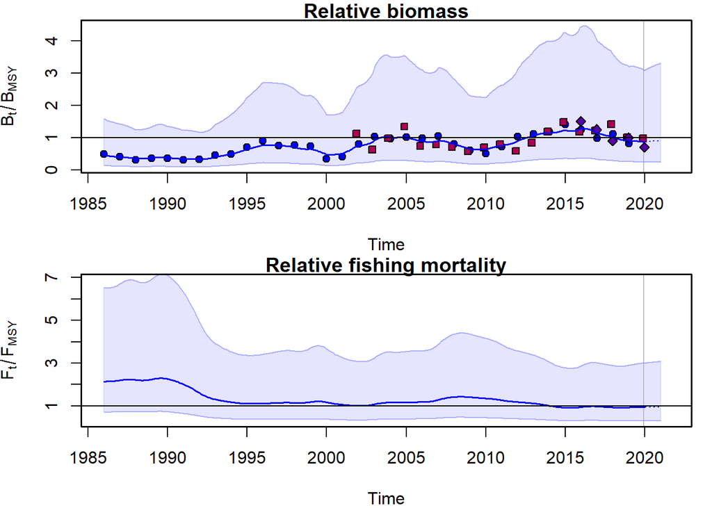

```r
# Plot the relative biomass and fishing mortality
par(mfrow = c(2, 1), mar = c(4, 4, 1, 1))
plotspict.bbmsy(res, qlegend = FALSE, stamp = "")
plotspict.ffmsy(res, qlegend = FALSE, stamp = "")
```

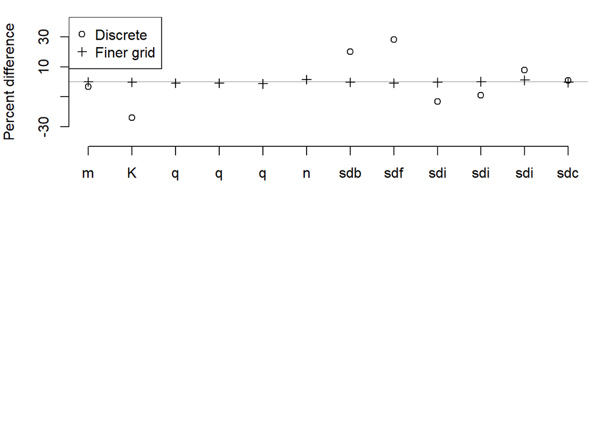

```r
# Check if there are changes in the results if the grid is finer, i.e.
# dteuler is smaller than 1/16 year.
inp.dteuler1_32 <- inp.ang
inp.dteuler1_32$dteuler <- 1/32
inp.dteuler1_32 <- check.inp(inp.dteuler1_32)

fit.dteuler1_32 <- fit.spict(inp.dteuler1_32)

## Fit the discrete time model
inp.dteuler1 <- inp.ang
inp.dteuler1$dteuler <- 1
inp.dteuler1 <- check.inp(inp.dteuler1)

fit.dteuler1 <- fit.spict(inp.dteuler1)

# Checked the fixed effects estimates
(par <- exp(res$par.fixed))
(par1 <- exp(fit.dteuler1$par.fixed))
(par1_32 <- exp(fit.dteuler1_32$par.fixed))

# Plot the percent change compared to the default run
dif1_32 <- (par - par1_32) / par * 100
dif1 <- (par - par1) / par * 100
plot(dif1, ylab = "Percent difference", xlab = "", axes = FALSE, ylim = c(-40,40))
points(dif1_32, pch = 3)
abline(h=0, col = "#00000044")
axis(1, at=seq(par), labels = gsub("log", "", names(par)))
axis(2, at = seq(-30, 30, 20))
legend("topleft", legend = c("Discrete", "Finer grid"), pch = c(1,3))

# Plot the results using the two dteuler together
par(mfrow = c(2,3))
```

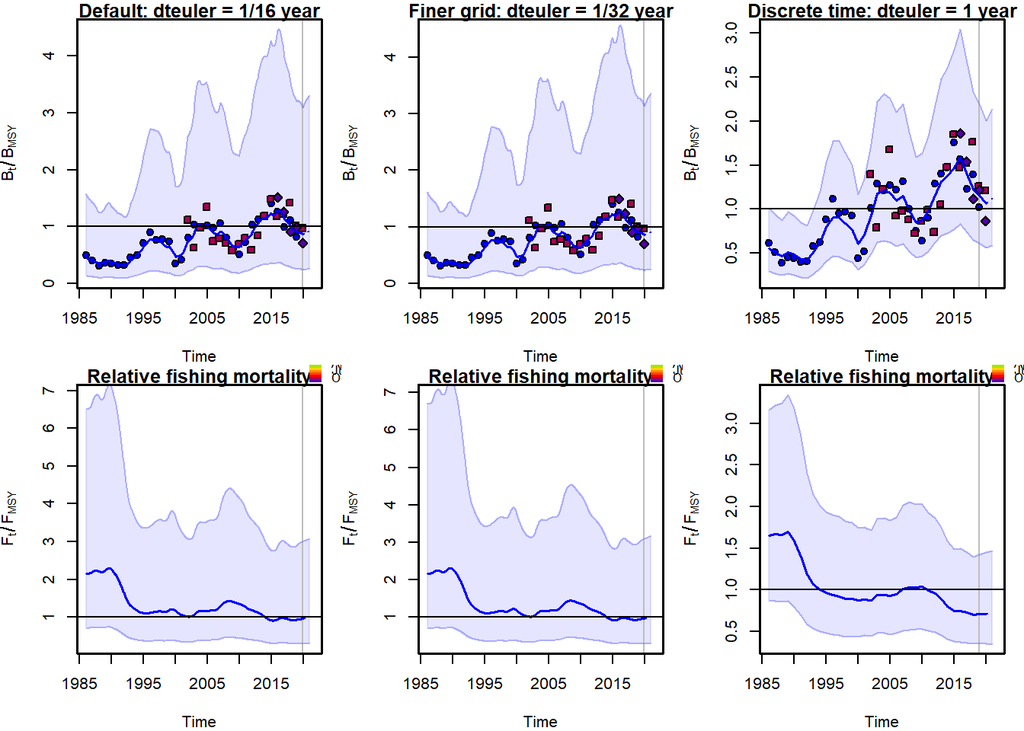

```r
plotspict.bbmsy(res, qlegend = FALSE, main = "")
title("Default: dteuler = 1/16 year")
plotspict.bbmsy(fit.dteuler1_32, qlegend = FALSE, main = "")
title("Finer grid: dteuler = 1/32 year")
plotspict.bbmsy(fit.dteuler1, qlegend = FALSE, main = "")
title("Discrete time: dteuler = 1 year")
plotspict.ffmsy(res)
plotspict.ffmsy(fit.dteuler1_32)
plotspict.ffmsy(fit.dteuler1)
```